# Introduction

90% of people globally have lost money while investing in the stock market. One of the main reasons has to do with the lack of knowledge about risk. Hence, our findings aim to aid investors in understanding volatility of stocks to make more informed decisions on purchasing and trading stocks. Specifically, it can guide investors in times of risk. Higher volatility in the market is typically associated with greater risk and leads to more uncertainty. In this case, with accurate stock data, an investor can adjust their strategy accordingly. Furthermore, having volatility information between earning and non-earning seasons helps investors analyze patterns and market fluctuations between long time frames in order to predict the optimal allocations for their investments.

Our question of interest states: During earnings periods (e.g., January, April, July, October), do the stock prices of these companies experience larger fluctuations compared to non-earnings periods (e.g., February, March, May, November). Our study aims to determine if earnings periods, compared to non-earnings periods, significantly affect stock price volatility for FAANG companies from 2012 to 2020, utilizing daily percentage changes in opening prices and the Difference in Means methodology.

Our findings suggest that there is no significant relationship between the mean variation of stock prices between earnings and non earning periods from 2012 to 2020.

[^1]

# Background

For our analysis, we decided to look into the stock prices in earning and non-earning periods from May 17, 2012 to August 02, 2020. The earning period includes January, April, July, October. The non-earning period includes February, March, May, and November. We observed this specific time period due to the fact that this range contains the complete data for all five FAANG companies we want to observe in our analysis.

The dataset was collected through web scraping of financial data from Yahoo Finance. This web scraping process involved extracting information related to the stock prices of the five prominent companies known as FAANG, which includes Facebook, Amazon, Apple, Netflix, and Google. Each case in the dataset represents a specific date or trading day. The dataset likely includes multiple rows, each corresponding to a different trading day, for each of the five FAANG companies. Each row contains various information about the stock prices and trading volumes for each trading day from 1980s - 2020s (depending on the company), we will be looking at the dataset from 2012-2020 since that is the earliest available data for all five companies.

[^2]

# Data context:

The key variables in our project are opening price, closing price, high price, low price, and date. The opening price is the price of a stock at the beginning of the trading day. The closing price is the price of a stock at the end of the trading day. The high price is the highest price reached by the stock during the trading day. The low price is the lowest price reached by the stock during the trading day. The date is the date of the trading day for which the stock price data is recorded. The data size of the dataset consists of multiple CSV files, with each file corresponding to one of the five FAANG companies. Each CSV file contains historical stock price data, typically with multiple rows, where each row represents a trading day. The total size of the dataset would depend on the time period covered but could include several years of daily trading data for each company.

Our data website: [^3]

# Report context:

To fully grasp the question we are posing in this project, we have to understand what an earning period is. An earning season is the time when public companies release their quarterly earnings report. This new piece of information is important because it can create volatility in the market. Another clarification to make is how we define “large fluctuations”. We will determine this by looking at the magnitude of change between the stock prices of the earning period vs the non earning period. In our question we explicitly state that we will be analyzing data from the five FAANG companies. The reason we narrowed it down to only those five was because these companies are the largest and most successful globally, and we were able to find solid data from these companies to use in our analysis. Lastly, we chose the time period of May 17, 2012 to August 02, 2020 because in order to effectively compare the five FAANG companies, we had to make sure we have complete data from all five companies.

There are several outlying factors that could influence our results but the four that have probably been the most obvious and well-known factors during recent times are the 2016 and 2020 Presidential elections, COVID-19, global political and economic conditions, and each of the FAANG companies’ individual policies have all influenced their stock market trends in one way or another. Hence, it’s impossible to say that our results would be 100% accurate.

In the report’s next phases, we will analyze stock price changes for FAANG companies from 2012 to 2020. Using graphs and stats like daily stock prices and market shifts, we will compare between earnings and non-earnings seasons. Using the information we find during these periods, we will create a statistical summary regarding our findings, considering any unusual circumstances in the data and suggesting ways to improve it.

# Graph

To better examine the distribution of variation for each of these periods, it would be useful to plot them against each other, as a boxplot. This would let us examine the distribution of each group side by side

### Key aspects of the boxplot:

The average fluctuation is calculated separately for earnings months and non-earnings months, where earnings months typically include periods such as January, April, July, and October, and non-earnings months include months like February, March, May, and November.

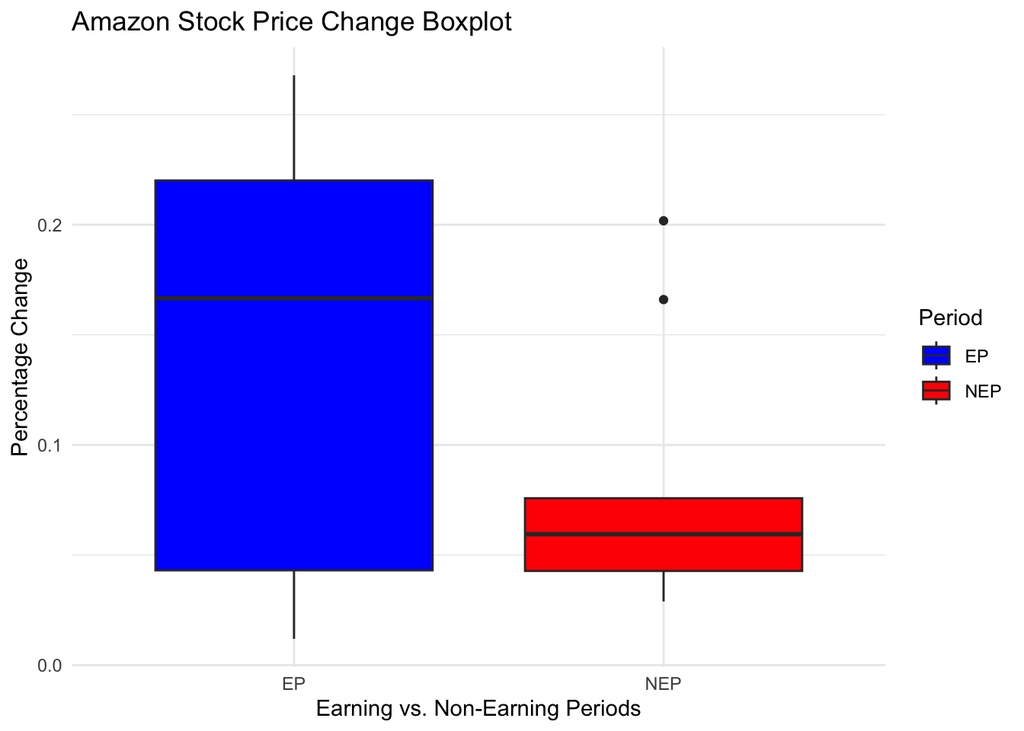

As we can see for Amazon, there seems to be a broader range of percentage changes for Earning Periods, while the Non Earning Periods have some outliers in a similar range.

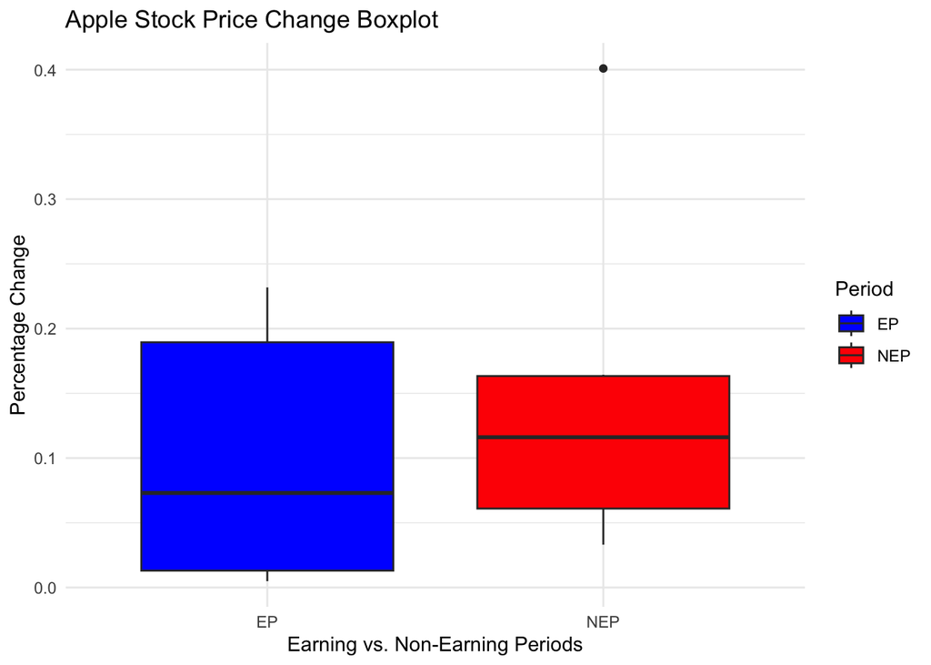

For Apple, it seems that the distribution is very similar, with the median for Earnings Periods being lower than Non Earnings Periods.

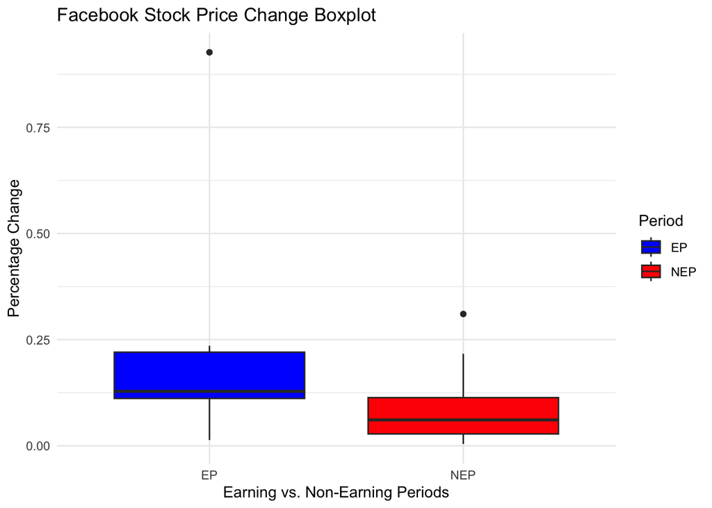

For Facebook, the Earnings Periods distribution is slightly above the Non Earnings Period but by a small value, their range of distribution is relatively similar.

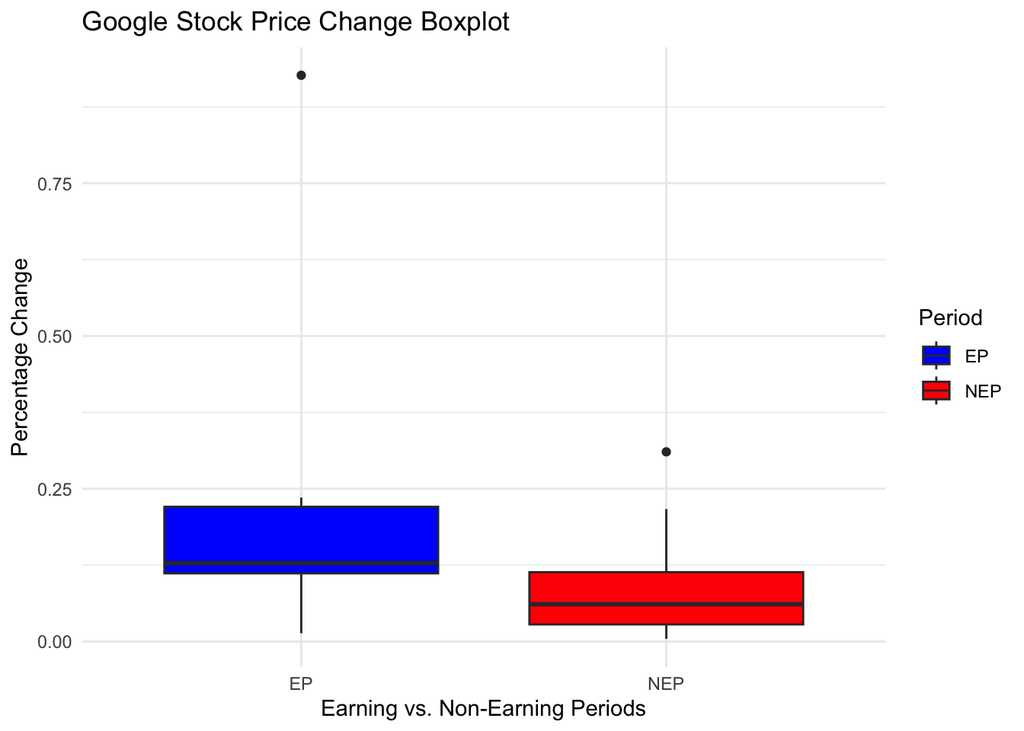

For Google, the situation is very similar to that of Facebook, with similar ranges and small differences.

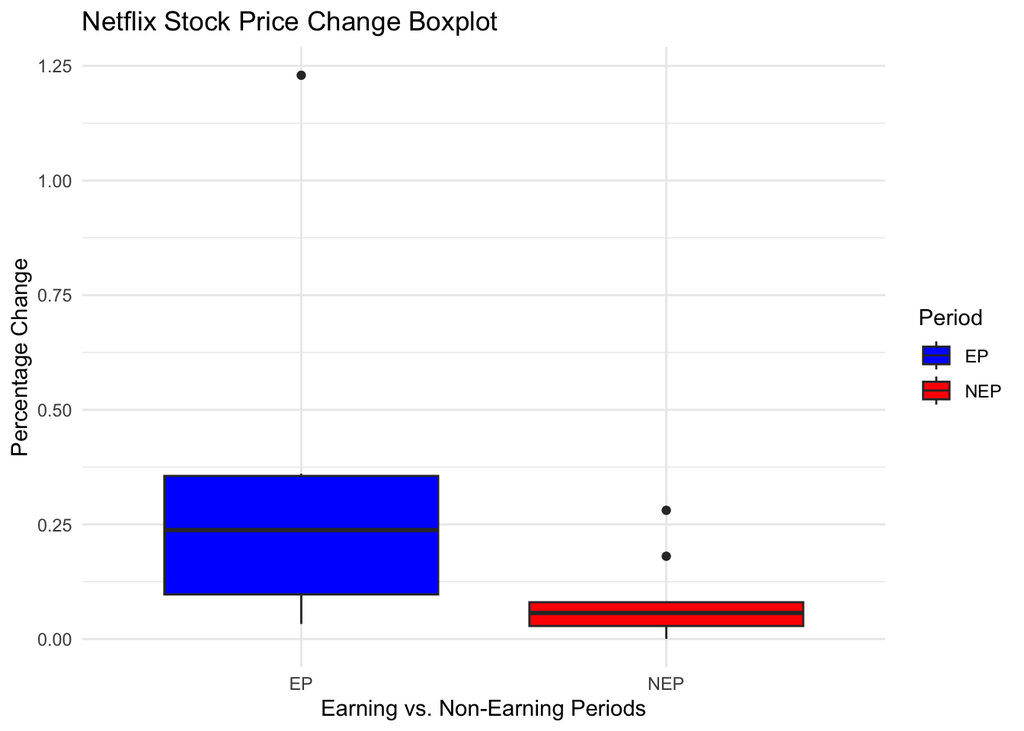

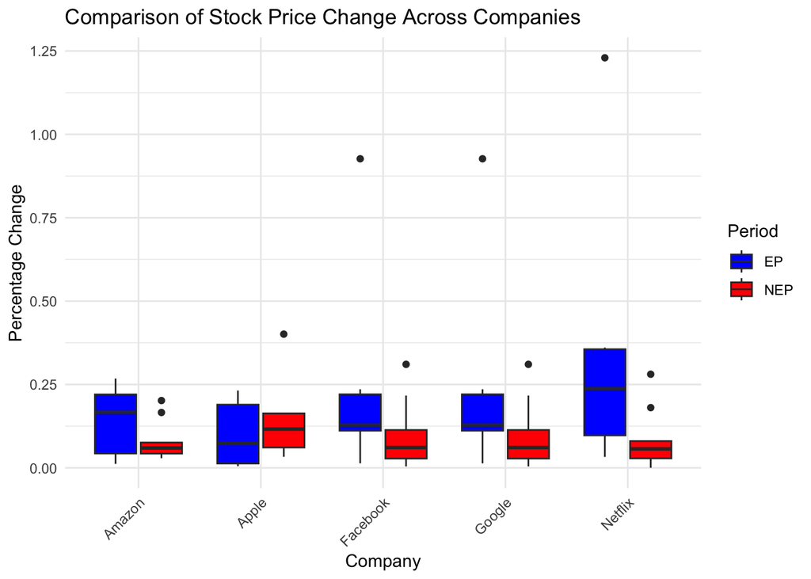

> To get some more information, let us plot these percentages, EP vs NEP, year by year.

The box plots are useful for examining the distribution of stock price changes overall for our entire time period. However, we can’t infer too much on how these two periods directly compare to each other as time progresses. Hence, we could use a line graph

A line graph could complement this by showing how the average fluctuation changes year over year, providing a clear picture of upward or downward trends.

For Amazon, we can see that they follow a similar trend up until 2016 when Earnings Months stay above the Non-Earnings Months until they meet at 2020.

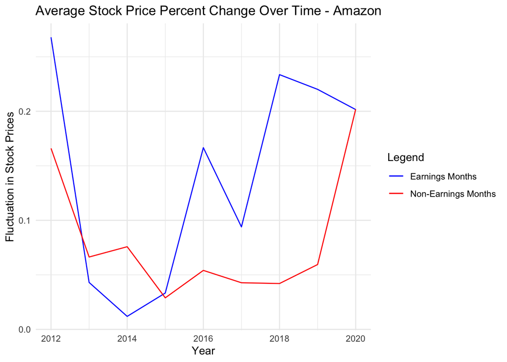

The Apple distribution for both periods are relatively consistent in it’s range of percentage changes for most of our data, except at 2020 where for Non Earnings Periods the percetnage change increased considerably more overall.

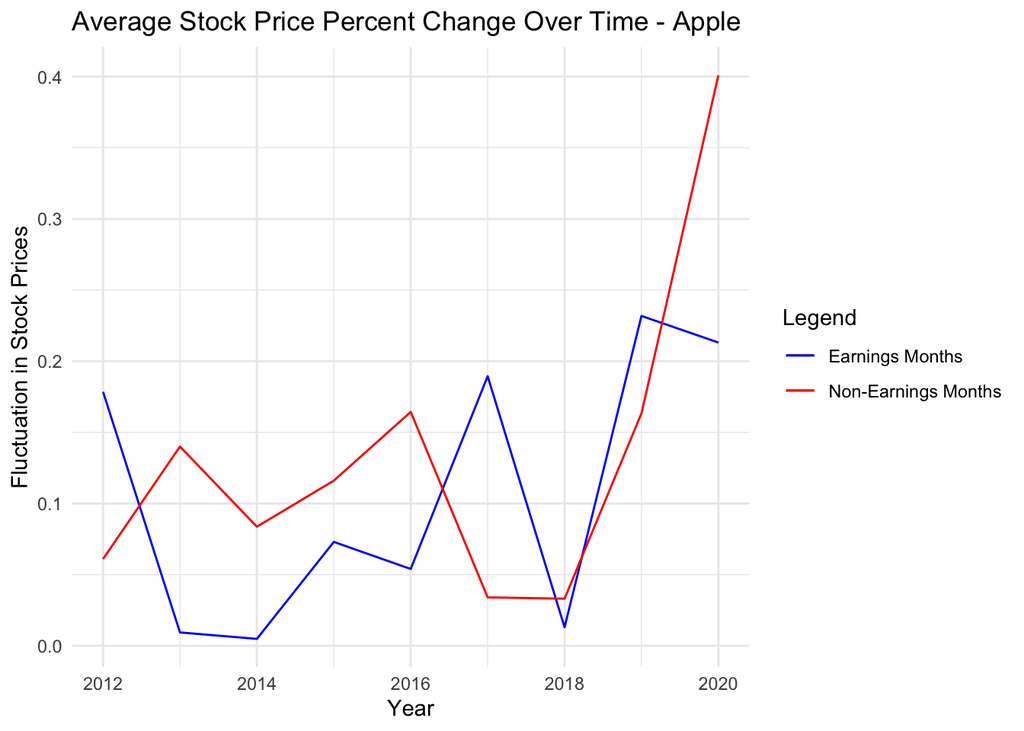

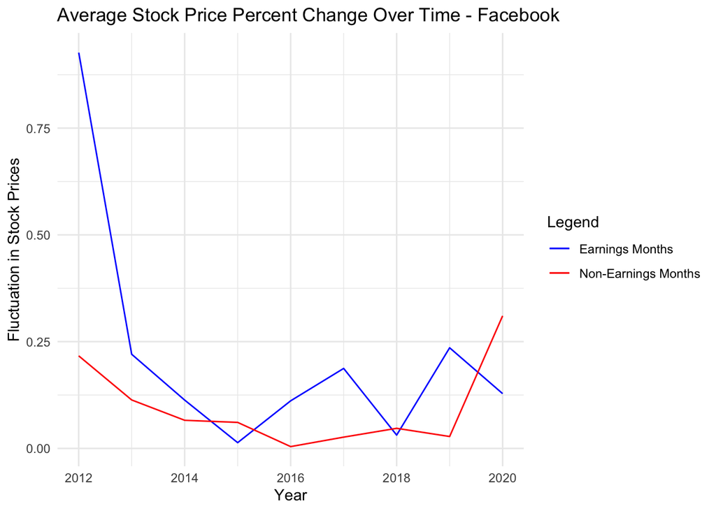

Google follows a similar trend as facebook where the distribution remains similar over time.

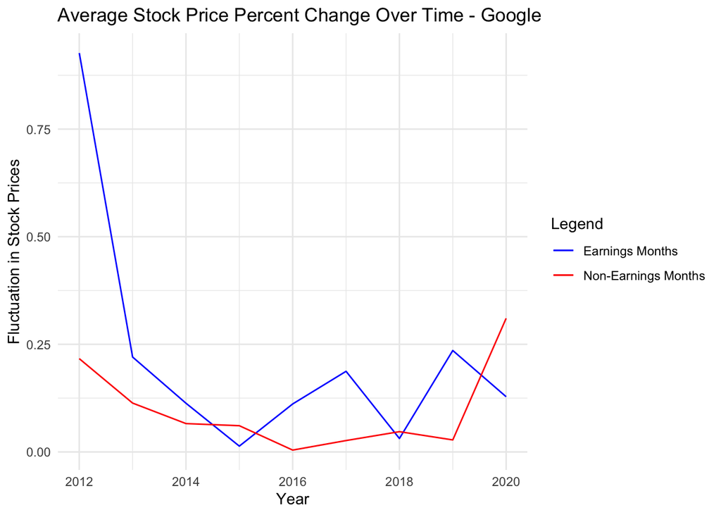

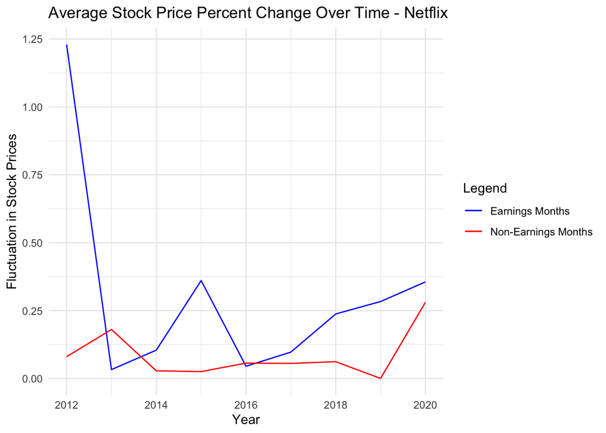

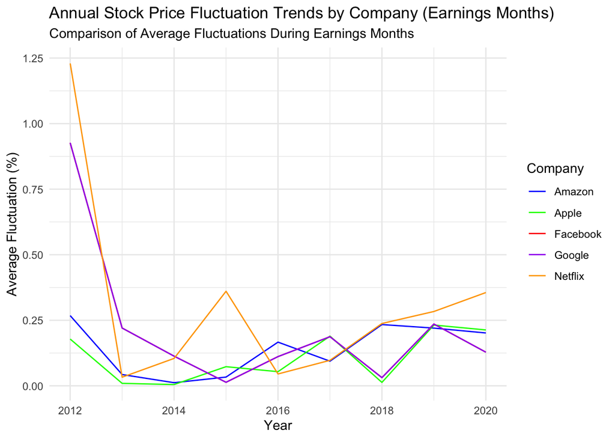

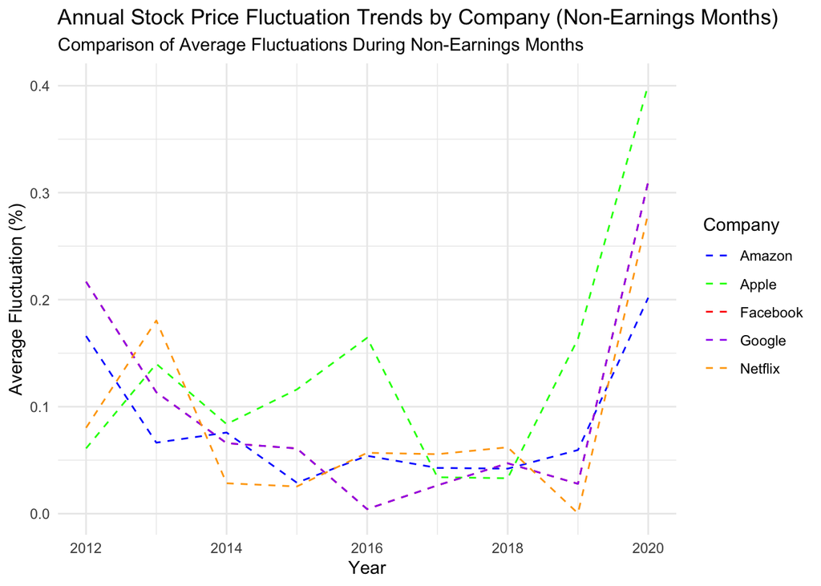

# Analysis

We will now conduct a difference of means t test between the Earning Periods and Non Earning Periods values for each company to see if there is a significant likelihood that their means vary. The Null Hypothesis is that there is no significant difference between the means of the two groups for a given company. The alternative Hypothesis is that there is a significant difference between the means of the two groups for a given company.

$H_0$: $\mu_{EP} = \mu_{NEP}$

The mean stock price fluctuation during the earning period ($\mu_{EP}$) is equal to the mean fluctuation during the non-earning period ($\mu_NEP$) for each companies.

$H_a$: $\mu_{EP} ≠ \mu_{NEP}$

The mean stock price fluctuation during the earning period ($\mu_{EP}$) is not equal to the mean fluctuation during the non-earning period ($\mu_{NEP}$) for each companies.

The Null Hypothesis is that the average stock price fluctuation during earning periods is exactly the same as during non-earning periods for each of the FAANG companies. Conversely, the Alternative Hypothesis posits that the true difference in means between these two periods is not equal to 0. The test statistic is calculated as the difference in the mean stock price fluctuation between earning and non-earning periods, divided by the standard error of this difference. In addition to reporting the p-value, we will provide the observed difference in means and the corresponding t statistic, which together give us a fuller understanding of the fluctuations’ behavior and significance.

The statistical analysis for Amazon revealed no significant difference in stock price fluctuations between Earning and Non-Earning Periods (p = 0.1417387), with a 95% confidence interval for the true mean difference ranging from -0.0226 to 0.1414. Similar non-significant results were observed for Facebook (p = 0.2433222, CI: -0.0967 to 0.3399), Google (p = 0.2433222, CI: -0.0967 to 0.3399), Netflix (p = 0.1170345, CI: -0.0671 to 0.5064), and Apple (p = 0.6102632, CI: -0.1296 to 0.0787). These findings suggest that there is no strong statistical evidence to support a difference in stock price movements during these periods for the companies analyzed.

In summary, our analysis does not provide overwhelming evidence to suggest significant differences in stock price fluctuations between Earning and Non-Earning Periods for any of the FAANG companies within the specified confidence intervals. These results are in line with our graphical analyses, which do not show stark contrasts between the two periods for these companies.

# Summary

This graph highlights the distribution of stock price fluctuations for the FAANG companies during Earning and Non-Earning Periods.

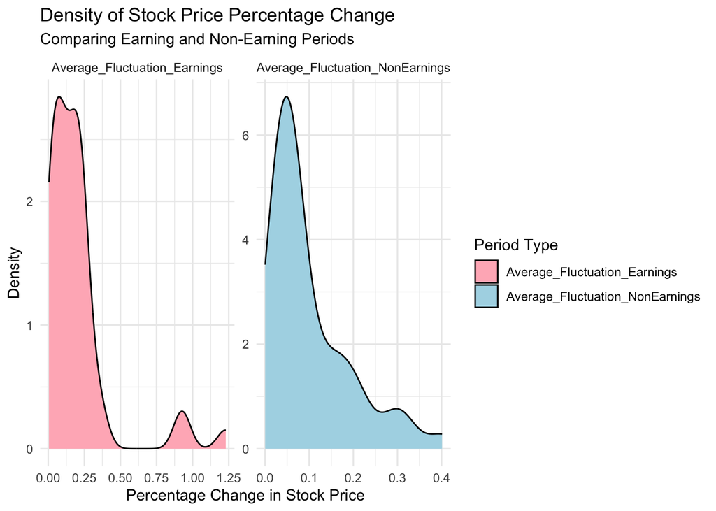